# ICVS exploration, assumption check, and contingency procedure

# 1 Data and variables

The relationship between country-level inequality and the consumption of security products will be tested using a multilevel linear regression. This analysis will be accomplished using a combination of three archival datasets.

Firstly, indicators of security consumption have been accessed from the International Crime Victimization survey (ICVS; REF), which is an accumulation of standardized sample surveys to look at householders’ experiences with crime, policing, crime prevention and feelings of unsafety. Although it does not consist of longitudinal observations, the ICVS has been distributed across five phases over fifteen years (1989, 1992, 1996, 2000, 2005), totaling 300,000 people and 78 different countries (Data Archiving and Networked Services, n.d.). For the purposes of this study, it is most notable that this survey contains items such as respondents’ adopted measures to protect themselves against burglary.

Secondly, nation-level inequality in disposable income was accessed through the Standardized World Income Inequality Database (SWIID; REF). The SWIID has been designed to maximize the comparability of income inequality data while maintaining the widest possible coverage across countries and over time. As a result, the gini coefficients are accompanied by standard errors to reflect uncertainty in the estimates.

Lastly, countries’ expenditure-side real GDP was retrieved from the Penn World Table, version 10.0 (PWT; REF). The selected GDP values are adjusted for Purchasing Power Parity, “to compare relative living standards across countries at a single point in time” (https://www.rug.nl/ggdc/productivity/pwt/?lang=en). Nations’ GDP values were divided by their population sizes to yield a per-capita GDP value, which will be used for these analysis.

# 2 Analysis procedure

If the assumptions underlying a multilevel regression hold in this dataset, the analysis will be conducted using maximum likelihood estimates (MLE) in r package lme4 (REF) as there are a relatively small number of level-2 units in this data. Likewise, the use of full maximum lilkelihood will enable the use of statistical weights

- Full maximum likelihood (FML)

the large sample size in this study will yield similar variance estimates to REML estimation.

Given that the SWIID is presented in alist of 100 different dataframes, the analysis will firstly be conducted on each dataframe, with the results stored separately.

```r
m1_null <- lmer(num_victim_5yr ~ 1+ (1 | country),REML = FALSE, data = join_sample)

summary(m1_null)
```

```
Linear mixed model fit by maximum likelihood  ['lmerMod']
Formula: num_victim_5yr ~ 1 + (1 | country)
   Data: join_sample

      AIC       BIC    logLik  deviance  df.resid
 211978.5  212006.5 -105986.2  211972.5     84123

Scaled residuals:
    Min      1Q  Median      3Q     Max
-1.2921 -0.6219 -0.4829  0.5515  7.6021

Random effects:
 Groups   Name        Variance Std.Dev.
 country  (Intercept) 0.03213  0.1793
 Residual             0.72624  0.8522
Number of obs: 84126, groups:  country, 31

Fixed effects:
            Estimate Std. Error t value
(Intercept)  0.55854    0.03237   17.25
```

```r
# Estimate model
m1_sample <- lme4::lmer(num_victim_5yr ~ gini_2004_6_cent + scale(gdppc_2004_6) +
                     age_cent + employed + male + (1 | country),data = join_sample, REML=FALSE)

# call basic unweighted model
summary(m1_sample)
```

```
Linear mixed model fit by maximum likelihood  ['lmerMod']
Formula: num_victim_5yr ~ gini_2004_6_cent + scale(gdppc_2004_6) + age_cent +
    employed + male + (1 | country)
   Data: join_sample

      AIC       BIC    logLik  deviance  df.resid
 210524.3  210599.0 -105254.2  210508.3     84118

Scaled residuals:
    Min      1Q  Median      3Q     Max
-1.5302 -0.6540 -0.4092  0.5360  7.6750

Random effects:
 Groups   Name        Variance Std.Dev.
 country  (Intercept) 0.01962  0.1401
 Residual             0.71383  0.8449
Number of obs: 84126, groups:  country, 31

Fixed effects:
                      Estimate Std. Error t value
(Intercept)          0.5525157  0.0262098  21.081
gini_2004_6_cent     0.0102624  0.0036537   2.809
scale(gdppc_2004_6) -0.0036955  0.0308283  -0.120
age_cent            -0.0064082  0.0001827 -35.069
employed1            0.0363263  0.0061857   5.873
male1               -0.0039138  0.0060088  -0.651

Correlation of Fixed Effects:
            (Intr) g_2004 s(_200 ag_cnt emply1
gn_2004_6_c -0.097
sc(_2004_6) -0.203  0.589
age_cent    -0.036  0.020  0.000
employed1   -0.105  0.009 -0.005  0.252
male1       -0.075 -0.004 -0.001 -0.020 -0.167
```

```r
# estimate weighted model - fails to converge even with all numeric variables scaled
m1_weight <- lme4::lmer(scale(num_victim_5yr) ~ scale(gini_2004_6) + scale(gdppc_2004_6) + scale(age_num) + employed + male + (1 | country),data = join_sample, REML=FALSE, weights = individual_weight)
```

```
Warning in checkConv(attr(opt, "derivs"), opt$par, ctrl = control$checkConv, :
Model failed to converge with max|grad| = 0.0216833 (tol = 0.002, component 1)
```

```
Warning in checkConv(attr(opt, "derivs"), opt$par, ctrl = control$checkConv, : Model is nearly unidentifiable: very large eigenvalue
 - Rescale variables?
```

```r
summary(join_sample[,c("num_victim_5yr", "gini_2004_6", "gdppc_2004_6_cent", "age_cent", "employed", "male")])
```

```
 num_victim_5yr    gini_2004_6    gdppc_2004_6_cent    age_cent
 Min.   :0.0000   Min.   :23.18   Min.   :-27877    Min.   :-27.98892
 1st Qu.:0.0000   1st Qu.:27.89   1st Qu.:-19569    1st Qu.:-12.98892
 Median :0.0000   Median :32.36   Median :  2022    Median : -2.98892
 Mean   :0.6246   Mean   :34.78   Mean   : -3490    Mean   :  0.07057
 3rd Qu.:1.0000   3rd Qu.:38.20   3rd Qu.:  7448    3rd Qu.: 12.01108
 Max.   :7.0000   Max.   :64.79   Max.   : 48937    Max.   : 28.01108
 employed  male
 0:40968   0:48620
 1:43158   1:35506
```

> The following steps are recommended assessing and resolving convergence warnings (also see examples below):

> double-check the model specification and the data

> adjust stopping (convergence) tolerances for the nonlinear optimizer, using the optCtrl argument to [g]lmerControl (see “Convergence controls” below)

> center and scale continuous predictor variables (e.g. with scale)

> double-check the Hessian calculation with the more expensive Richardson extrapolation method (see examples)

> restart the fit from the reported optimum, or from a point perturbed slightly away from the reported optimum

> use allFit to try the fit with all available optimizers (e.g. several different implementations of BOBYQA and Nelder-Mead, L-BFGS-B from optim, nlminb, …). While this will of course be slow for large fits, we consider it the gold standard; if all optimizers converge to values that are practically equivalent, then we would consider the convergence warnings to be false positives

> The first of the 100 element-long list will be used for exploring influential observations and model residuals (these elements will vary solely on gini values).

# 3 Exploration

Starting with scatterplots. Nation Values with a cook’s distance of 4 times the mean cook’s distance values are flagged

## 3.1 Influential observations

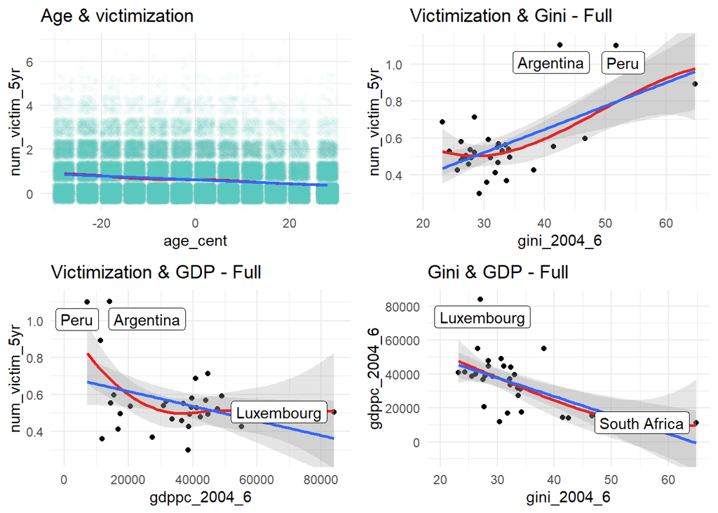

## 3.2 Model-based exploration

Now there are obviously some heavy tails in this data.

Further seen in the normality statistics for the residuals - high skewness and kurtosis

```r
moments::skewness(resid(m1_sample))
```

```
[1] 1.477563
```

```r
moments::kurtosis(resid(m1_sample))
```

```
[1] 5.721236
```

> Note that this is based on simple aggregates It is not based on empirical Bayesian estimates Doesn’t take sampling variation due to sampling of into account Therefore a rough guide, but only rough

### 3.2.1 Cook’s distance ( R package influence.ME )

```r
# influential cases (Cook's Distance. Any values over 1 are likely to be significant outliers)
cooksD <- cooks.distance(m1_sample)
summary(cooksD)
```

```
     Min.   1st Qu.    Median      Mean   3rd Qu.      Max.
0.000e+00 1.188e-05 2.477e-05 6.205e-05 4.692e-05 5.379e-03
```

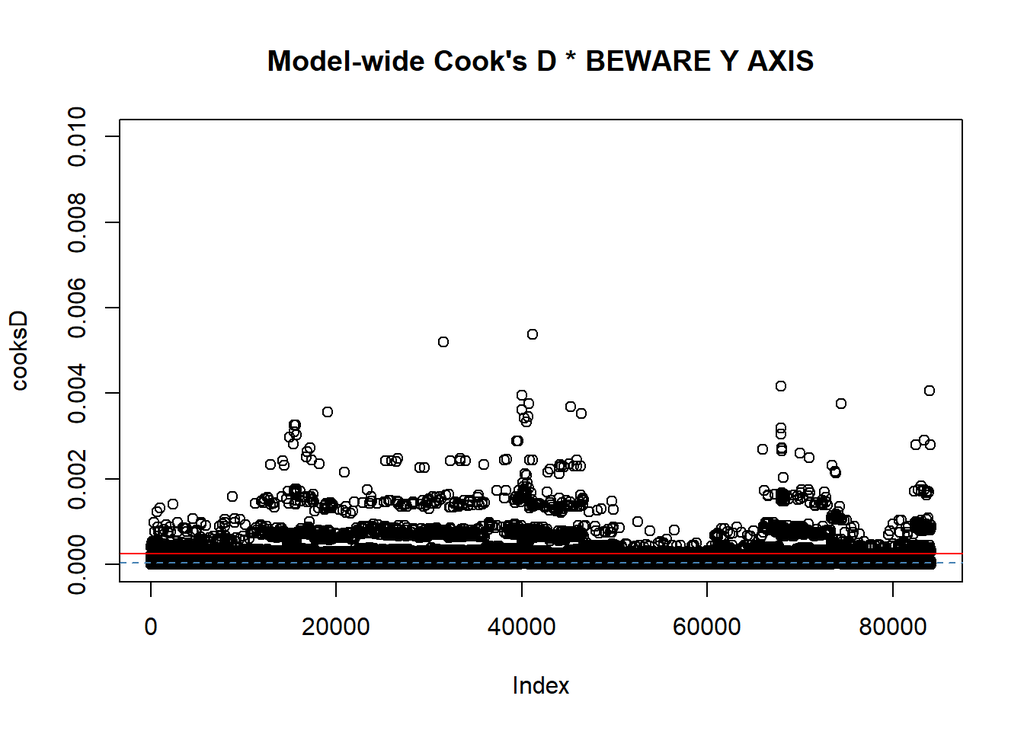

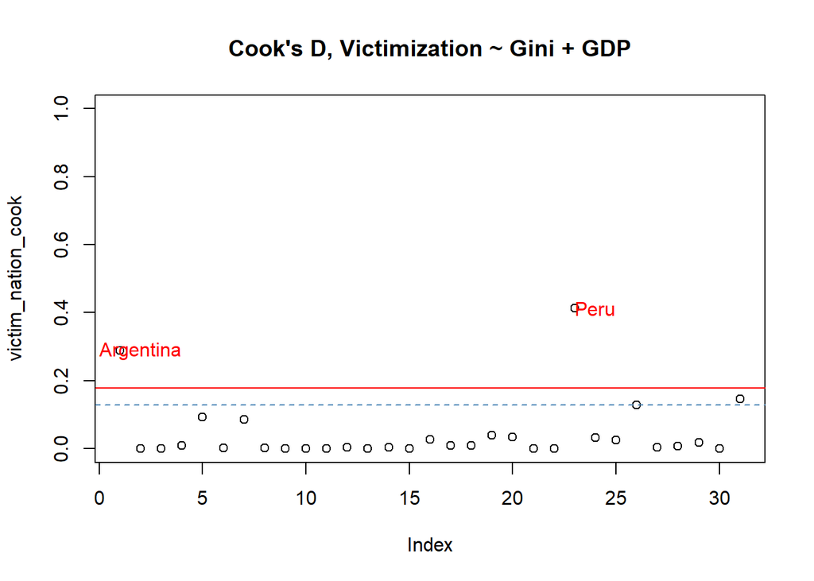

A model-wide Cook’s D shows that any given observation has a small influence on the entire model - to be expected with such a large sample. This is why it’s important to break the analysis of influential variables into multiple levels

We can see that level-2 analysis yields much larger Cook’s D values. The cooks distance values are all well under 1. Importantly, this is the same for the nation-level variables; they have a smaller sample size - and are thus the more susceptible to influential observations.

I would prefer to use an r package for my analyses (lme4, EdSurvey, WeMix, BIFIEsurvey ). However, we saw that lme4 runs into convergence problems; likewise the other packages are so new and specific that they don’t generate objects that can be used for analyses like cook’s distance.

By contrast, Stata is far more developed for multilevel analysis with survey weights. If we’re going to use a package that doesn’t have great integration with r, we might as well use the program that best handles the statistics.

```r
join_sample <- rename(join_sample, iw_mcity = individual_weight_for_main_cities
         , iw_lastmcity = individual_weight_for_last_main_city
       , iw_nat = individual_weight_for_national_surveys
       , lik_elected = likely_elected_minicipal_councilors
       )

haven::write_dta(join_sample,"C:/Users/dalla/Google Drive/project_files/icvs_inequality/data/joined_sample.dta")
```

```stata
use "C:\Users\dalla\Google Drive\project_files\icvs_inequality\data\joined_sample.dta", clear

mixed num_victim_5yr  || country:

estat icc
```

```
Performing EM optimization:

Performing gradient-based optimization:

Iteration 0:   log likelihood = -105986.23
Iteration 1:   log likelihood = -105986.23  (backed up)

Computing standard errors:

Mixed-effects ML regression                     Number of obs     =     84,126
Group variable: country                         Number of groups  =         31

                                                Obs per group:
                                                              min =        790
                                                              avg =    2,713.7
                                                              max =     10,284

                                                Wald chi2(0)      =          .
Log likelihood = -105986.23                     Prob > chi2       =          .

------------------------------------------------------------------------------
num_victim~r |      Coef.   Std. Err.      z    P>|z|     [95% Conf. Interval]
-------------+----------------------------------------------------------------
       _cons |   .5585389   .0323748    17.25   0.000     .4950855    .6219923
------------------------------------------------------------------------------

------------------------------------------------------------------------------
  Random-effects Parameters  |   Estimate   Std. Err.     [95% Conf. Interval]
-----------------------------+------------------------------------------------
country: Identity            |
                  var(_cons) |   .0321336   .0082208      .0194624    .0530546
-----------------------------+------------------------------------------------
               var(Residual) |   .7262365   .0035417      .7193281    .7332113
------------------------------------------------------------------------------
LR test vs. linear model: chibar2(01) = 6444.99       Prob >= chibar2 = 0.0000


Intraclass correlation

------------------------------------------------------------------------------
                       Level |        ICC   Std. Err.     [95% Conf. Interval]
-----------------------------+------------------------------------------------
                     country |   .0423719   .0103826      .0260972    .0680864
------------------------------------------------------------------------------
```

```stata
use "C:\Users\dalla\Google Drive\project_files\icvs_inequality\data\joined_sample.dta"

# First model
xtmixed num_victim_5yr gini_2004_6_cent gdppc_2004_6_cent age_cent employed male [pw=individual_weight] || country:, pwscale(size)

mltcooksd, fixed random graph
estat ic
```

```
Unknown #command

Obtaining starting values by EM:

Performing gradient-based optimization:

Iteration 0:   log pseudolikelihood =  -103671.5
Iteration 1:   log pseudolikelihood =  -103671.5  (backed up)

Computing standard errors:

Mixed-effects regression                        Number of obs     =     84,126
Group variable: country                         Number of groups  =         31

                                                Obs per group:
                                                              min =        790
                                                              avg =    2,713.7
                                                              max =     10,284

                                                Wald chi2(5)      =     189.29
Log pseudolikelihood =  -103671.5               Prob > chi2       =     0.0000

                               (Std. Err. adjusted for 31 clusters in country)
------------------------------------------------------------------------------
             |               Robust
num_victim~r |      Coef.   Std. Err.      z    P>|z|     [95% Conf. Interval]
-------------+----------------------------------------------------------------
gini_2004_~t |   .0130299   .0038207     3.41   0.001     .0055414    .0205184
gdppc_2004~t |   2.28e-07   1.90e-06     0.12   0.905    -3.50e-06    3.96e-06
    age_cent |  -.0067583   .0006306   -10.72   0.000    -.0079943   -.0055223
    employed |   .0258464   .0168435     1.53   0.125    -.0071663     .058859
        male |   .0019442   .0122159     0.16   0.874    -.0219986     .025887
       _cons |   .4936049   .0352765    13.99   0.000     .4244641    .5627456
------------------------------------------------------------------------------

------------------------------------------------------------------------------
                             |               Robust
  Random-effects Parameters  |   Estimate   Std. Err.     [95% Conf. Interval]
-----------------------------+------------------------------------------------
country: Identity            |
                   sd(_cons) |   .1447085   .0290432      .0976465    .2144527
-----------------------------+------------------------------------------------
                sd(Residual) |   .8291228   .0356986      .7620257    .9021279
------------------------------------------------------------------------------

Warning: Sampling weights were specified only at the first level in a
         multilevel model. If these weights are indicative of overall and not
         conditional inclusion probabilities, then results may be biased.

Level 2 variable is country

Calculating DFBETAs for the fixed effects of
 gini_2004_6_cent gdppc_2004_6_cent age_cent employed male _cons

error obtaining scores for robust variance
r(430);

end of do-file
r(430);
```

```stata
# use "C:\Users\dalla\Google Drive\project_files\icvs_inequality\data\joined_sample.dta", clear
```

[output not shown]

```stata
use "C:\Users\dalla\Google Drive\project_files\icvs_inequality\data\joined_sample.dta"

# Winzorized model
xtmixed num_victim_5yr_winz gini_2004_6_wc gdppc_2004_6_ws age_cent employed male [pw=individual_weight] || country:, pwscale(size)

mltcooksd, fixed random graph

estat ic
```

[output not shown]

# 4 Main stats

pseudo-loglikelihoods: can’t be compared

**BIC**: Stands for “Bayesian Information Criteria” A non-parametric approach to model fit Basically produces a fit statistic that looks at model fit relative to the number of predictors Penalizes improvement in model fit if it took a large number of predictors

There’s no baseline to the BIC, so you can’t use it as an overall indicator of model fit However, you can use it as a relative measure of model Which of two models is better Typically, you want the lowest BIC possible

strength of evidence : 0-2 - weak; 2-6 = positive, 6-10 = strong, > 10 = very strong

AIC

# 5 Handling influential observations - Winzorization

Since these influential observations are not a mistake - but rather truly extreme data, we will not delete the data, but instead winzorize these extreme values.

```
 num_victim_5yr   num_victim_5yr_winz  gdppc_2004_6   gdppc_2004_6_winz
 Min.   :0.0000   Min.   :0.0000      Min.   : 7091   Min.   :11574
 1st Qu.:0.0000   1st Qu.:0.0000      1st Qu.:15398   1st Qu.:15398
 Median :0.0000   Median :0.0000      Median :36989   Median :36989
 Mean   :0.6246   Mean   :0.5686      Mean   :31478   Mean   :31760
 3rd Qu.:1.0000   3rd Qu.:1.0000      3rd Qu.:42415   3rd Qu.:42415
 Max.   :7.0000   Max.   :2.0000      Max.   :83904   Max.   :55136
  gini_2004_6    gini_2004_6_winz
 Min.   :23.18   Min.   :25.02
 1st Qu.:27.89   1st Qu.:27.89
 Median :32.36   Median :32.36
 Mean   :34.78   Mean   :34.22
 3rd Qu.:38.20   3rd Qu.:38.20
 Max.   :64.79   Max.   :48.93
```

Dramatic changes to the max values, less-so for the mean values (with the exception of number of victimizations)

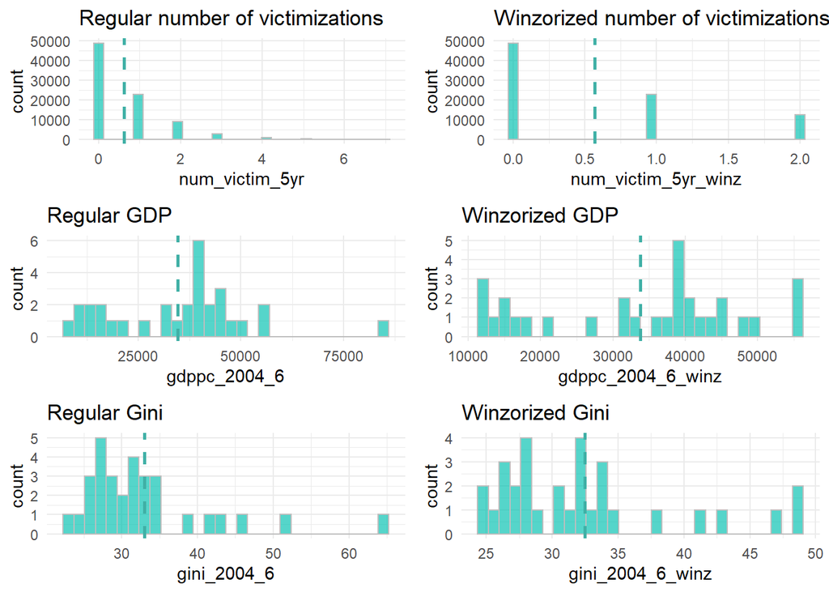

## 5.1 Winzorized plots

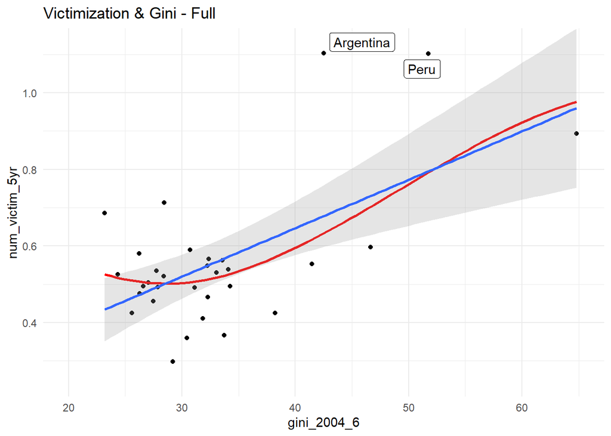

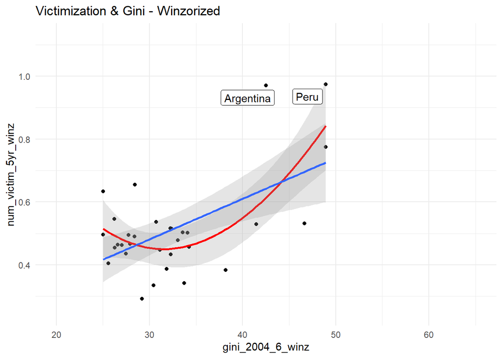

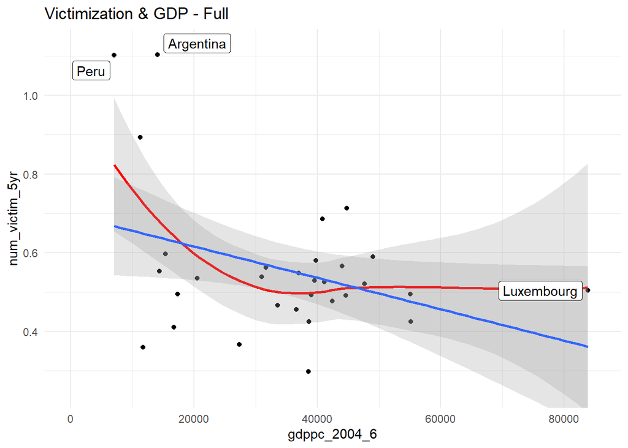

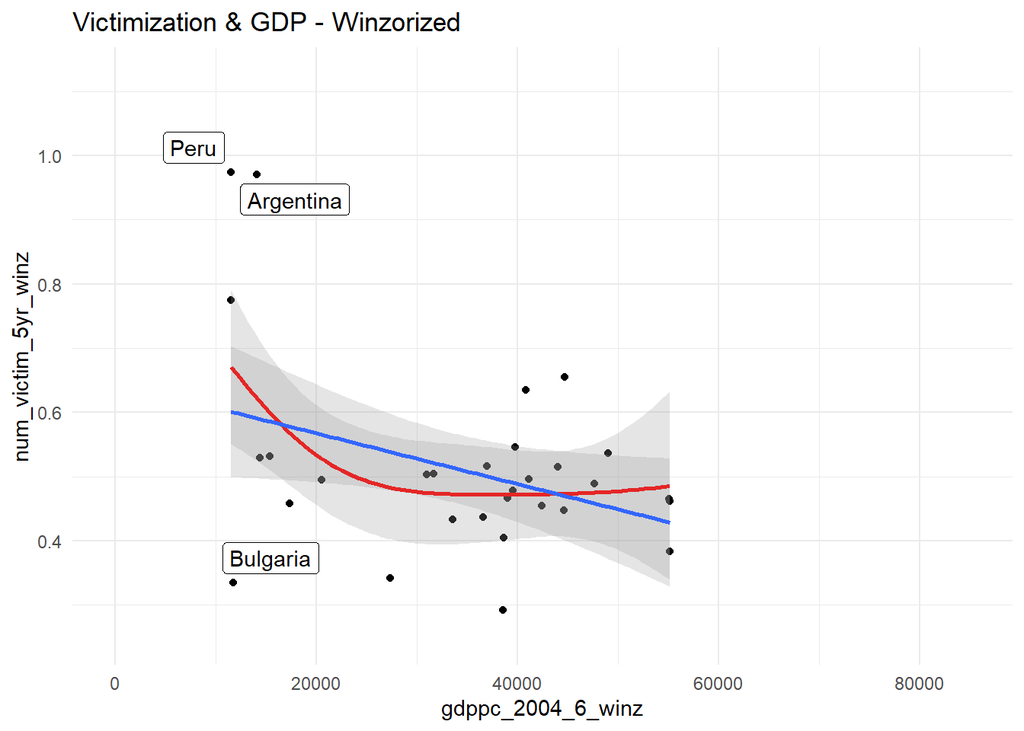

## 5.2 Winzorized model

```r
m1_winz <- lme4::lmer(num_victim_5yr_winz ~ gini_2004_6_wc + gdppc_2004_6_wc +
                     age_cent + as.factor(employed) + as.factor(male) + (1 | country),data = join_sample, REML=FALSE)

# m2_winz <- lme4::lmer(num_victim_5yr_winz ~ gini_2004_6_wc + gdppc_2004_6_wc +
#                      age_cent + employed + male + (1 | country),data = join_sample, REML=FALSE, weights = individual_weight)

summary(m1_winz)
```

```
Linear mixed model fit by maximum likelihood  ['lmerMod']
Formula: num_victim_5yr_winz ~ gini_2004_6_wc + gdppc_2004_6_wc + age_cent +
    as.factor(employed) + as.factor(male) + (1 | country)
   Data: join_sample

     AIC      BIC   logLik deviance df.resid
179155.0 179229.7 -89569.5 179139.0    84118

Scaled residuals:
    Min      1Q  Median      3Q     Max
-1.6184 -0.7279 -0.4632  0.7090  2.6368

Random effects:
 Groups   Name        Variance Std.Dev.
 country  (Intercept) 0.0148   0.1217
 Residual             0.4916   0.7012
Number of obs: 84126, groups:  country, 31

Fixed effects:
                       Estimate Std. Error t value
(Intercept)           5.113e-01  2.233e-02  22.893
gini_2004_6_wc        1.035e-02  4.313e-03   2.401
gdppc_2004_6_wc      -1.775e-07  2.105e-06  -0.084
age_cent             -5.529e-03  1.516e-04 -36.462
as.factor(employed)1  2.890e-02  5.134e-03   5.629
as.factor(male)1     -7.819e-03  4.987e-03  -1.568

Correlation of Fixed Effects:
             (Intr) gn_2004_6_ gd_2004_6_ ag_cnt as.fctr(mp)1
gn_2004_6_w   0.080
gdp_2004_6_   0.079  0.646
age_cent     -0.035  0.018      0.001
as.fctr(mp)1 -0.104  0.005     -0.007      0.252
as.fctr(ml)1 -0.074 -0.004     -0.001     -0.020 -0.167
fit warnings:
Some predictor variables are on very different scales: consider rescaling
```

```r
# summary(m2_winz)
```

```r
moments::skewness(resid(m1_winz))
```

```
[1] 0.7985318
```

```r
moments::kurtosis(resid(m1_winz))
```

```
[1] 2.584907
```

Winzorizing does a good job of reducing skewness and kurtosis, but definitely not back to normality. Skewness was reduced from 1.48 to 0.8, and kurtosis reduced from *5.72* to *2.58*

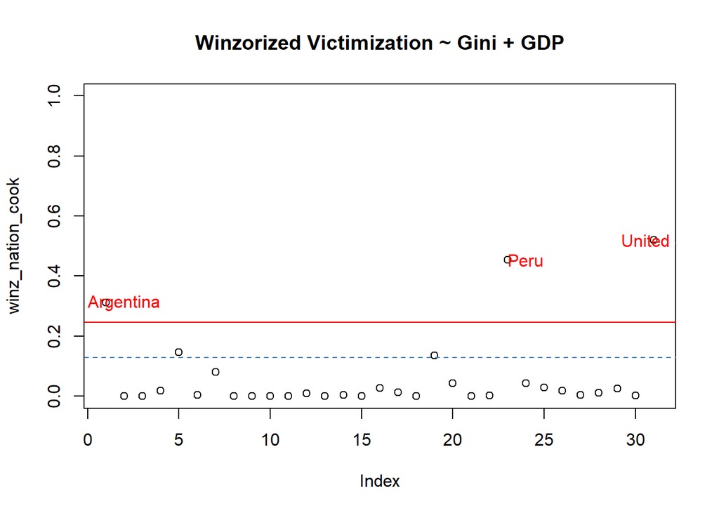

Winzorizing doesn’t appear to reign in the Cook’s D scores of Peru and Argentina, the biggest offenders. It ends up actually increasing the influence of the United States. However, it reduces the skew and kurtosis of the data…

> When Ruiter and de Graaf (2010) excluded 23 cases based on DFBETAS, they found that their results held The point is that ultimately you need to have analyses that you can defend under scrutiny

> Some suggest absolute values of greater than 1 Cohen et al. (2003); Fox (2003) But Fox (2003) points out that this may not be effective large samples Cites additional research suggesting 2/(square root of n) This rule was also used by Van der Meer et al (2010:175) n refers to the n at the specific level, in this case level-2

> when I have around 30 clusters, I tend to depend on an absolute value of 1

> Unlike an OLS model, if we exclude a case at level-2, we also lose additional cases, in terms of all the cases at level-1 associated with that unit Van de Meer et al (2010) suggest retaining the level-1 cases, and then adding a dummy variable at level-2 to control for their unit That is, 0=not in excluded unit, 1=in excluded unit Also fix intercept to 0 for this cluster

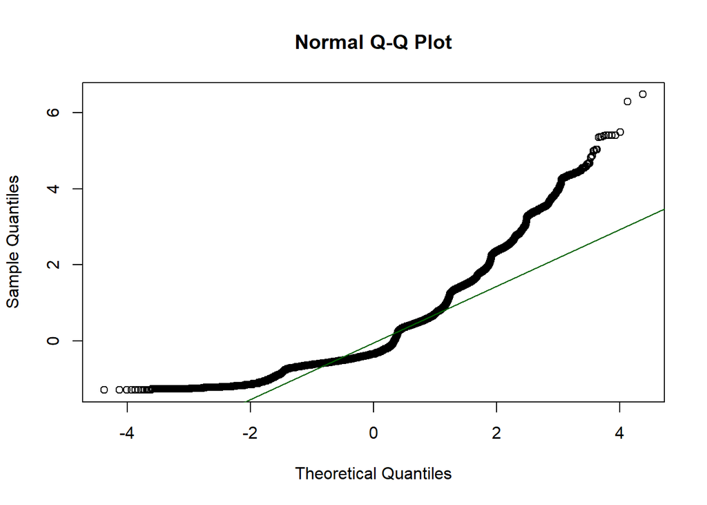

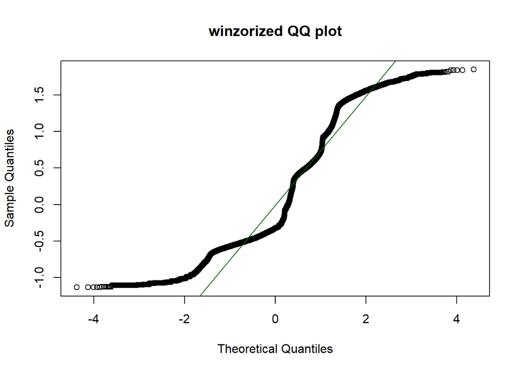

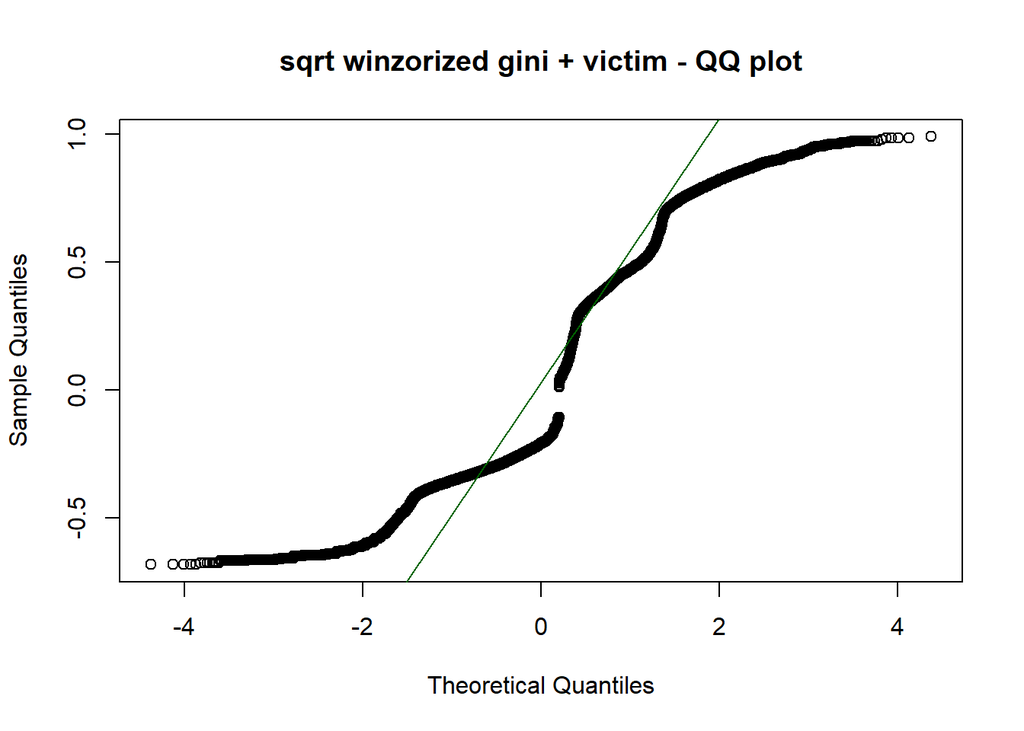

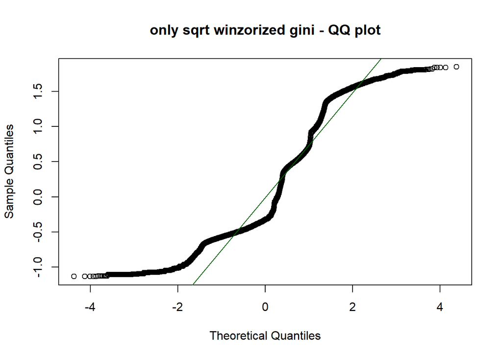

Winzorizing definitely seems to help the normality of the model. Again, it does not remedy normality by any stretch; there are still some very heavy tails

Interestingly, winzorizing with no other transformations seems to have the same (best) fit to the qq line

# 6 Assumption checks and and contingencies

## 6.1 Linearity

- **Check:** Scatterplots for nonlinear relationships
- **Treatment:** If robust nonlinear relationship detected, add polynomials until adequate fit to linear function is obtained

Nonlinearity does not seem to be a major issue in the data. There may be some pattern of as much as a third-order polynomial in the effects of gini on victimization, (second-order for GDP).

Especially with a small sample at level-2, adding polynomials seems more likely to risk overfitting the data. I would only assess the fit of a polynomial model if I could then test it on another dataset, for cross-validation.

## 6.2 Normality in residuals

- **Check**: QQplots (The Normal Probability Plot method.) for whether lie on normal distribution

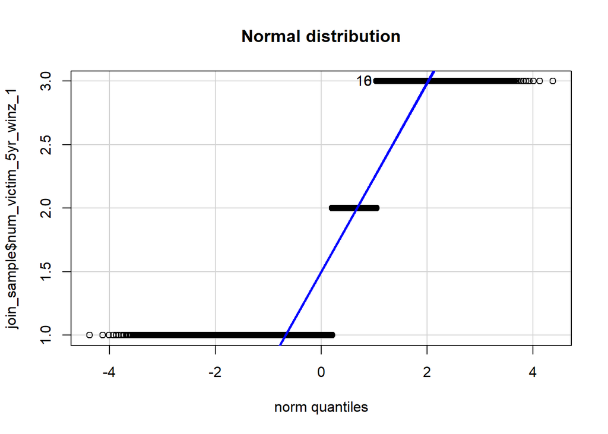

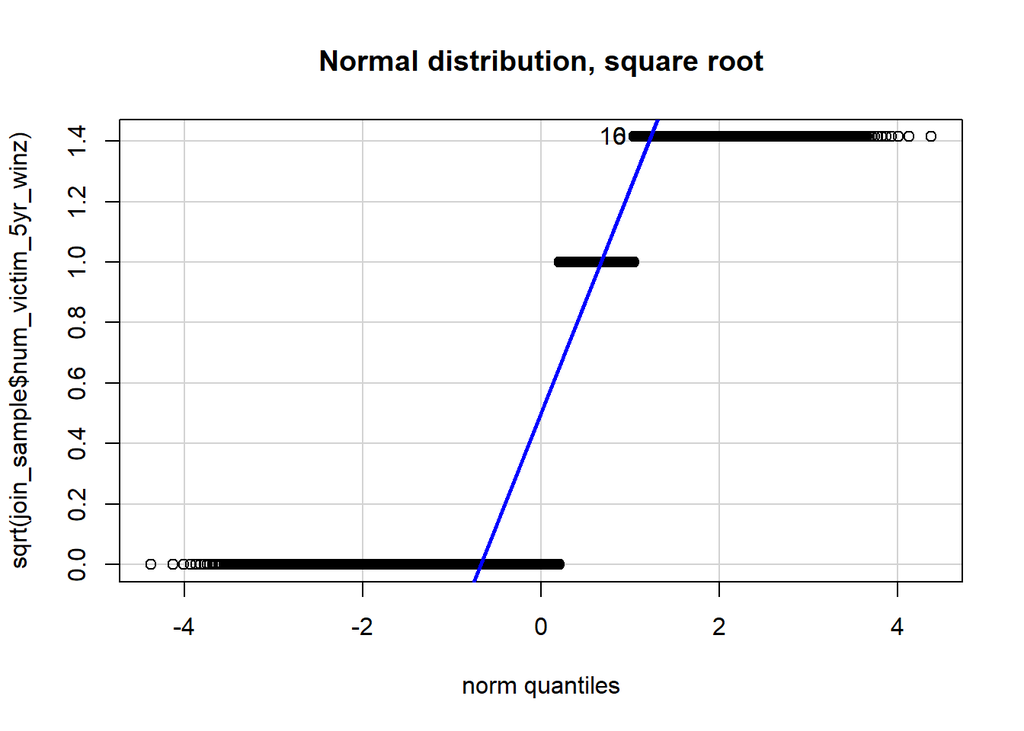

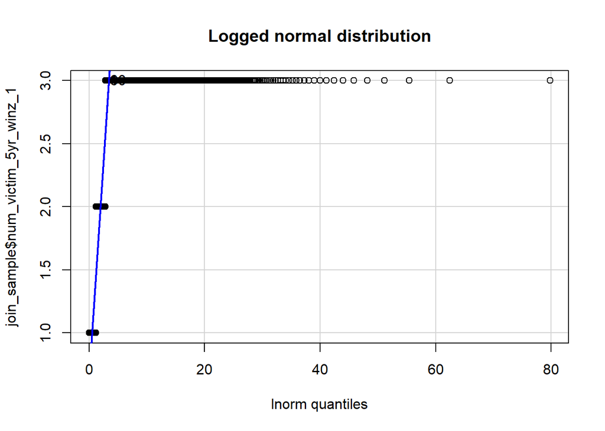

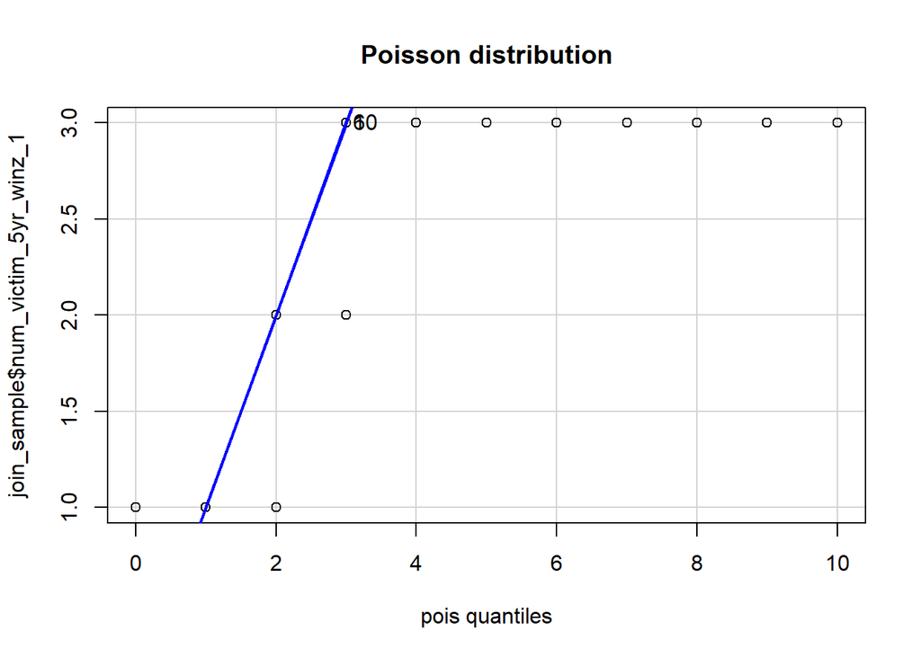

**On alternate error distributions**

Initially, a poisson process seems to better describe the distribution of this study’s dependent variable. However, the variables *num_victim_5yr* and *security_total* each likely violate the assumption of event independence, where one event does not affect the likelihood of a subsequent event. For instance, in the case of security consumption, the psychological and material impacts of buying a security product (e.g., feelings of safety, reduced budget), can plausibly impact a consumers’ decision to purchase further security goods. Knief & Forstmeier (2021) found a Gaussian error distribution to be far more robust to violations of its assumptions than Poisson and Binomial distributions. Given the potential for heavy bias in poisson and negative binomial models, a gaussian error structure’s comparative robustness appears to make a (violated) assumption of normality be the most appropriate choice compared to a possibly misattributed poisson distribution.

Knief & Forstmeier, 2021

> Poisson distribution - lambdas specify variance and mean of the distribution (doesn’t have to be an integer)

> We have shown that Poisson models yielded heavily biased type I error rates (at α = 0.05) in either direction ranging from 0 to as high as 0.55 when their distribution assumption is violated (Fig. 3 right column, Fig. S7).

> Moreover, we worry that sophisticated methods may allow presenting nearly anything as statistically significant (Simmons et al., 2011) because complex methods will only rarely be questioned by reviewers.

> Moreover, we worry that sophisticated methods may allow presenting nearly anything as statistically significant (Simmons et al., 2011) because complex methods will only rarely be questioned by reviewers.

DFBeta values: difference between estimate including and deleting outlier

DFFit: difference between adjusted predicted value and original value

## 6.3 Heteroscedasticity (Homogeneity of Variance)

- **Check**: Plot residuals vs predicted values, for changes in residual variance across levels of predicted values
  - Others: Breush-Pagan test and the NCV test, levene’s test (Fligner-Killeen test - this is a non-parametric test which is very robust against departures from normality)
- **Fix** with Box-Cox transformation of DV; caret::BoxCoxTrans(yvar); boxcoxmix; log transformation of DV; integrate weights in robust methods using robustmm::rlmer()
- **Stopping rule:**

### 6.3.1 Survey Weights

The package lme4 fits mixed models when there are no weights or weights only for first-level units (Bates, Maechler, Bolker, & Walker, 2015)

> one does not need to de-emphasize responses from smaller nations because the MLM separates out variance due to responses from individuals in a country from the variance that comes from different nations. With the level-1 weight, the individual responses are representative of a nation, and the MLM then considers the cross-national context separately from this

> a scaled weight indicates that there was first a random sampling of clusters, and then a sampling of individuals in clusters. But, here, we looked at a set of randomly sampled people within specific nations

> Conceptually, we get around this by assuming that the characteristics we are examining are representative of a broader set of nations with similar characteristics But, for the purposes of weighting, there really isn’t any probability of selection at level-2 to adjust by

> We essentially treat each nation as a whole equal unit, and then adjust only for sampling characteristics within the nation

Potential Packages: EdSurvey WeMix : appears to require two weights BIFIEsurvey : appears to allow one weight being used - but only level 2

```r
# # conditional (scaled?) weights
# data$pwt2 <- data$w_fschwt
# data$pwt1 <- data$w_fstuwt / data$w_fschwt
```

The WeMix package assumes that the weights are unconditional—as is typical for sample weights found on international surveys such as PISA—but can accept conditional weights by setting the cWeights argument to TRUE.

https://www.r-project.org/nosvn/pandoc/lme4.html

> Recent/release notes Recent versions of lme4 (e.g. 1.1-6) give false convergence warnings. There is a summary post on r-sig-mixed-models. If you get warnings about max|grad| but the model passes this test: dd <- fit@optinfo$derivs with(dd,max(abs(solve(Hessian,gradient)))<2e-3) then you are seeing a false-positive warning, and the problem will disappear in future versions (1.1-7 and up).

```r
m1_null <- lme4::lmer(num_victim_5yr ~ 1 + (1 | country), data = join_sample, REML=FALSE, weights = individual_weight)
```

```
Warning in checkConv(attr(opt, "derivs"), opt$par, ctrl = control$checkConv, :
Model failed to converge with max|grad| = 0.00431948 (tol = 0.002, component 1)
```

```
Warning in checkConv(attr(opt, "derivs"), opt$par, ctrl = control$checkConv, : Model is nearly unidentifiable: very large eigenvalue
 - Rescale variables?
```

```r
m1_stand <- lme4::lmer(num_victim_5yr ~ gini_2004_6_wc + gdppc_2004_6_ws +
                     age_cent + as.factor(employed) + as.factor(male) + (1 | country), data = join_sample, REML=FALSE)

m1_weight_stand <- lme4::lmer(num_victim_5yr ~ gini_2004_6_wc + gdppc_2004_6_ws +
                     age_cent + as.factor(employed) + as.factor(male) + (1 | country), data = join_sample, REML=FALSE, weights = individual_weight)
m2_weight_stand <- lme4::lmer(num_victim_5yr ~ gini_2004_6_ws + gdppc_2004_6_ws +
                     age_s + as.factor(employed) + as.factor(male) + (1 | country), data = join_sample, REML=FALSE, weights = individual_weight)
summary(join_sample[,c("num_victim_5yr_cent", "gini_2004_6_ws", "gdppc_2004_6_ws", "age_s", "employed", "male")])
```

```
Error in (function (cond) : error in evaluating the argument 'object' in selecting a method for function 'summary': Can't subset columns that don't exist.
x Column `num_victim_5yr_cent` doesn't exist.
```

```r
join_sample1 <- filter(join_sample, country != "United Kingdom")


m2_stand <- lme4::lmer(num_victim_5yr ~ gini_2004_6_ws + gdppc_2004_6_ws +
                     age_s + as.factor(employed) + as.factor(male) + (1 | country), data = join_sample1, REML=FALSE, weights = individual_weight)
dd <- m1_stand@optinfo$derivs
with(dd,max(abs(solve(Hessian,gradient)))<2e-3)
```

```
[1] TRUE
```

```r
# m1_glm <- lme4::glmer(num_victim_5yr ~ gini_2004_6_ws + gdppc_2004_6_ws +
#                      age_s + employed + male + (1 | country), data = join_sample, family = "poisson", weights = individual_weight)

summary(join_sample[,c("gini_2004_6_ws", "gdppc_2004_6_ws", "age_cent", "country", "male", "employed", "individual_weight")])
```

```
  gini_2004_6_ws.V1    gdppc_2004_6_ws.V1     age_cent
 Min.   :-1.1279016   Min.   :-1.6206194   Min.   :-27.98892
 1st Qu.:-0.7095763   1st Qu.:-1.3468672   1st Qu.:-12.98892
 Median :-0.0595783   Median : 0.1985366   Median : -2.98892
 Mean   : 0.2116279   Mean   :-0.1757637   Mean   :  0.07048
 3rd Qu.: 0.7899796   3rd Qu.: 0.5869363   3rd Qu.: 12.01108
 Max.   : 2.3523288   Max.   : 1.4974299   Max.   : 28.01108
   country          male      employed  individual_weight
 Length:84125       0:48619   0:40967   Min.   :    1
 Class :character   1:35506   1:43158   1st Qu.: 4042
 Mode  :character                       Median : 8194
                                        Mean   : 8273
                                        3rd Qu.:11687
                                        Max.   :19927
```

```r
ss <- getME(m1_stand, c("theta", "fixef"))
restart <- update(m1_stand, start=ss, control=lmerControl(optCtrl = list(maxfun=2e4)))
summary(restart)
```

```
Linear mixed model fit by maximum likelihood  ['lmerMod']
Formula: num_victim_5yr ~ gini_2004_6_wc + gdppc_2004_6_ws + age_cent +
    as.factor(employed) + as.factor(male) + (1 | country)
   Data: join_sample
Control: lmerControl(optCtrl = list(maxfun = 20000))

      AIC       BIC    logLik  deviance  df.resid
 210522.5  210597.3 -105253.3  210506.5     84117

Scaled residuals:
    Min      1Q  Median      3Q     Max
-1.5305 -0.6540 -0.4092  0.5359  7.6740

Random effects:
 Groups   Name        Variance Std.Dev.
 country  (Intercept) 0.01967  0.1403
 Residual             0.71384  0.8449
Number of obs: 84125, groups:  country, 31

Fixed effects:
                       Estimate Std. Error t value
(Intercept)           0.5528012  0.0257879  21.436
gini_2004_6_wc        0.0134012  0.0049754   2.693
gdppc_2004_6_ws      -0.0006085  0.0339262  -0.018
age_cent             -0.0064087  0.0001827 -35.072
as.factor(employed)1  0.0363032  0.0061858   5.869
as.factor(male)1     -0.0039163  0.0060088  -0.652

Correlation of Fixed Effects:
             (Intr) gn_2004_6_ gd_2004_6_ ag_cnt as.fctr(mp)1
gn_2004_6_w   0.080
gdp_2004_6_   0.079  0.646
age_cent     -0.036  0.019      0.001
as.fctr(mp)1 -0.109  0.006     -0.007      0.252
as.fctr(ml)1 -0.077 -0.004     -0.001     -0.020 -0.167
```

```r
# m1_stand <- lme4::lmer(num_victim_5yr ~ gini_2004_6_wc + gdppc_2004_6_wc +
#                      age_cent + employed + male + (1 | country), data = join_sample, REML=FALSE, weights = individual_weight)


summary(m1_stand)
```

```
Linear mixed model fit by maximum likelihood  ['lmerMod']
Formula: num_victim_5yr ~ gini_2004_6_wc + gdppc_2004_6_ws + age_cent +
    as.factor(employed) + as.factor(male) + (1 | country)
   Data: join_sample

      AIC       BIC    logLik  deviance  df.resid
 210522.5  210597.3 -105253.3  210506.5     84117

Scaled residuals:
    Min      1Q  Median      3Q     Max
-1.5305 -0.6540 -0.4092  0.5359  7.6740

Random effects:
 Groups   Name        Variance Std.Dev.
 country  (Intercept) 0.01967  0.1403
 Residual             0.71384  0.8449
Number of obs: 84125, groups:  country, 31

Fixed effects:
                       Estimate Std. Error t value
(Intercept)           0.5528012  0.0257879  21.436
gini_2004_6_wc        0.0134012  0.0049754   2.693
gdppc_2004_6_ws      -0.0006085  0.0339262  -0.018
age_cent             -0.0064087  0.0001827 -35.072
as.factor(employed)1  0.0363032  0.0061858   5.869
as.factor(male)1     -0.0039163  0.0060088  -0.652

Correlation of Fixed Effects:
             (Intr) gn_2004_6_ gd_2004_6_ ag_cnt as.fctr(mp)1
gn_2004_6_w   0.080
gdp_2004_6_   0.079  0.646
age_cent     -0.036  0.019      0.001
as.fctr(mp)1 -0.109  0.006     -0.007      0.252
as.fctr(ml)1 -0.077 -0.004     -0.001     -0.020 -0.167
```

```r
# summary(lme4::allFit(m1_stand))
#
# m1_glm <- lme4::glmer(num_victim_5yr ~ gini_2004_6_ws + gdppc_2004_6_ws +
#                      age_s + employed + male + (1 | country), family="poisson", data = join_sample,  weights = individual_weight)
#
# summary(m1_glm)
```

```r
join_sample$null_lv2_weight <- 1

m1_wemix_null <- mix(num_victim_5yr_winz ~ 1+ (1 | country),data = join_sample, weights=c("individual_weight","null_lv2_weight"))

# same results as stata mixed num_victim_5yr  || country:

summary(m1_wemix_null)
```

```
Call:
mix(formula = num_victim_5yr_winz ~ 1 + (1 | country), data = join_sample,
    weights = c("individual_weight", "null_lv2_weight"))

Variance terms:
 Level    Group        Name Variance Std. Error Std.Dev.
     2  country (Intercept)  0.02616    0.01141   0.1617
     1 Residual              0.48684    0.02540   0.6977
Groups:
 Level   Group n size mean wgt  sum wgt
     2 country     31        1 3.10e+01
     1     Obs  84125     8273 6.96e+08

Fixed Effects:
            Estimate Std. Error t value
(Intercept)  0.49119    0.02953   16.63

lnl= -737084339.56
Intraclass Correlation= 0.051
```

```r
# weighted model with null level 2 weight - "1" conditional weights - similar, but not identical to stata -  intercept seems way off
#mixed num_victim_5yr gini_2004_6_cent gdppc_2004_6_cent age_cent employed male [pw=individual_weight] || country:, pweight(1) pwscale(size)

m1_wemix <- mix(num_victim_5yr ~ gini_2004_6 + gdppc_2004_6_cent + age_cent + employed + male + (1 | country),data = join_sample, weights=c("individual_weight","null_lv2_weight"))
summary(m1_wemix)
```

```
Call:
mix(formula = num_victim_5yr ~ gini_2004_6 + gdppc_2004_6_cent +
    age_cent + employed + male + (1 | country), data = join_sample,
    weights = c("individual_weight", "null_lv2_weight"))

Variance terms:
 Level    Group        Name Variance Std. Error Std.Dev.
     2  country (Intercept)   0.0211   0.008373   0.1453
     1 Residual               0.6922   0.060327   0.8320
Groups:
 Level   Group n size mean wgt  sum wgt
     2 country     31        1 3.10e+01
     1     Obs  84125     8273 6.96e+08

Fixed Effects:
                    Estimate Std. Error t value
(Intercept)        8.747e-02  1.236e-01   0.708
gini_2004_6        1.300e-02  3.790e-03   3.431
gdppc_2004_6_cent  2.655e-07  1.887e-06   0.141
age_cent          -6.781e-03  6.508e-04 -10.420
employed1          2.780e-02  1.713e-02   1.623
male1              1.872e-03  1.258e-02   0.149

lnl= -859553478.08
Intraclass Correlation= 0.02958
```

```r
m2_wemix <- mix(num_victim_5yr_winz ~ gini_2004_6_wc + gdppc_2004_6_ws + age_cent + employed + male + (1 | country),data = join_sample, weights=c("individual_weight","null_lv2_weight"))

summary(m2_wemix)
```

```
Call:
mix(formula = num_victim_5yr_winz ~ gini_2004_6_wc + gdppc_2004_6_ws +
    age_cent + employed + male + (1 | country), data = join_sample,
    weights = c("individual_weight", "null_lv2_weight"))

Variance terms:
 Level    Group        Name Variance Std. Error Std.Dev.
     2  country (Intercept)  0.01543   0.005078   0.1242
     1 Residual              0.47660   0.025085   0.6904
Groups:
 Level   Group n size mean wgt  sum wgt
     2 country     31        1 3.10e+01
     1     Obs  84125     8273 6.96e+08

Fixed Effects:
                  Estimate Std. Error t value
(Intercept)      0.4832107  0.0217344  22.233
gini_2004_6_wc   0.0134142  0.0053592   2.503
gdppc_2004_6_ws  0.0026815  0.0321193   0.083
age_cent        -0.0058545  0.0005342 -10.959
employed1        0.0222699  0.0123233   1.807
male1           -0.0029536  0.0093721  -0.315

lnl= -729687921.70
Intraclass Correlation= 0.03137
```

```r
#
# m3_wemix <- mix(num_victim_5yr ~ gini_2004_6_wc + gdppc_2004_6_ws + age_cent + employed + male + (1 | country),data = join_sample, weights=c("individual_weight","null_lv2_weight"))
#
#
# summary(m3_wemix)



m1_wemix_cweight <- mix(num_victim_5yr ~ gini_2004_6_cent + gdppc_2004_6_cent + age_cent + employed + male + (1 | country),data = join_sample, weights=c("individual_weight","null_lv2_weight"), cWeights = TRUE)
#https://rdrr.io/cran/WeMix/f/vignettes/Introduction_to_Mixed_Effects_Models_With_WeMix.Rmd
# In HLM, we fit the most similar model we could get the software to fit, but it is not the same, so the results are different. Similar to the one random effect model, Stata mixed reports a lower standard error for the random intercept than most other models. In terms of the standard errors of the fixed effects, differences are evident between the estimates of all the programs; \texttt{WeMix} most closely matches Stata mixed.


summary(m1_wemix_cweight)
```

```
Call:
mix(formula = num_victim_5yr ~ gini_2004_6_cent + gdppc_2004_6_cent +
    age_cent + employed + male + (1 | country), data = join_sample,
    weights = c("individual_weight", "null_lv2_weight"), cWeights = TRUE)

Variance terms:
 Level    Group        Name Variance Std. Error Std.Dev.
     2  country (Intercept)   0.0211   0.008346   0.1453
     1 Residual               0.6922   0.060327   0.8320
Groups:
 Level   Group n size mean wgt  sum wgt
     2 country     31        1 3.10e+01
     1     Obs  84125     8273 6.96e+08

Fixed Effects:
                    Estimate Std. Error t value
(Intercept)        5.201e-01  2.441e-02  21.309
gini_2004_6_cent   1.300e-02  3.790e-03   3.431
gdppc_2004_6_cent  2.655e-07  1.887e-06   0.141
age_cent          -6.781e-03  6.508e-04 -10.420
employed1          2.780e-02  1.713e-02   1.623
male1              1.872e-03  1.258e-02   0.149

lnl= -859553478.08
Intraclass Correlation= 0.02958
```

```r
cooks.distance(m2_wemix)
```

```
Error in UseMethod("cooks.distance"): no applicable method for 'cooks.distance' applied to an object of class "WeMixResults"
```

```r
lsdf <- EdSurvey::getData(sdf, c("composite","dsex","b017451","scrpsu","origwt","smsrswt"),
addAttributes=TRUE)
```

```
Error in checkDataClass(data, c("edsurvey.data.frame", "light.edsurvey.data.frame", : object 'sdf' not found
```

```r
m1_edsurvey <- EdSurvey::mixed.sdf(num_victim_5yr_winz ~ (1 | country),data = join_sample,
weightVar = c('individual_weight', "null_lv2_weight"), fast=TRUE, verbose=1,
addAttributes=TRUE)
```

```
Error in checkDataClass(data, c("edsurvey.data.frame", "light.edsurvey.data.frame")): The argument 'data' must be an edsurvey.data.frame or a light.edsurvey.data.frame. See "Using the 'EdSurvey' Package's getData Function to Manipulate the NAEP Primer Data vignette" for how to work with data in a li…
```

https://m-clark.github.io/mixed-models-with-R/issues.html#convergence > Any complicated GLMM or similar model is likely to have problems, so be prepared. If you want to go beyond GLM, you’ll have fewer tools and likely more issues. There are packages like ordinal, mgcv, glmmTMB, and others that can potentially handle alternate distributions and other complexities, however I think one might be better off with a Bayesian approach (e.g. brms/rstan). In practice, I’ve found others to be prohibitively slow, unable to converge, or too limited in post-estimation options.

Dr. B

> One must use weights when the sample design is “informative”(Koziol et al. 2017) The “design features—stratification, clustering, disproportionate-sampling—are associated with the response variable of interest” (Heeringa et al. 2010:59) One can render the design uninformative if controls render selection probabilities unrelated to outcome (Koziol et al. 2017)

> In the weights are uninformative, then one can omit the weights from model estimation (Heeringa et al. 2010:381) The issue here is that weights often account for more that just post-stratification, and these are likely to be associated with your outcome In other words, you will typically need to include weights in your MLM

On putting weights into MLM

> The issue here is that the weight we were using in design-based approaches is based on the individual probability of selection In other words, this weight includes adjustment for selection of clusters, such as PSU’s (West et al. 2014) The problem here is that what we want is a weight that adjusts for selection, given the probability that the PSU was selected

> In other words, the sampling weight is the combination of the probability of a cluster being chosen and the individual in that cluster being chosen

> What we want then, is to isolate each weight. The cluster weight is the inverse probability that the weight was chosen

> The appropriate level-1 weight is then one’s total inverse probability, scaled to the probability that one’s cluster was chosen

> GET THE SCALED WEIGHT: This creates the inverse probability that one was chosen, relative to the inverse probability that their cluster was chosen Essentially scales one’s overall probability to the cluster probability

> we can’t just drop a weight created from a design-based approach into a model-based approach The bigger issue here is that many surveys do not provide information specifically on cluster-level probabilities of selection that would allow us to easily scale our design-based weights

> SCALING: Two approaches that are common are the PWIGLS method 2 and the MPML method A

> Chen (2018), a researcher with the Add Health study, argues in a presentation that the PWIGLS method is recommended when informative sampling methods are used in sampling both levels. In other words, if one does not have an SRS at both levels

> Stapleton (2013:379) indicates that both methods require sampling weights at each level, which is problematic if we don’t have sampling weights for the PSU or cluster level

> If you do not have cluster-level weights, and you have a random sample of clusters, you are on more tenuous ground, but it may be possible to estimate the cluster-level weights

> Carl’s (2009) simulation study concluded, "Scaled weighted estimates and standard errors differed slightly from unweighted analyses, agreeing more with each other than with unweighted analyses

> it appears more important to scale than use a very specific form of scaling

weights when there isn’t a probability of level-2 selection

> This is therefore a case in which we simply drop in our level-1 weight without re-scaling We essentially treat each nation as a whole equal unit, and then adjust only for sampling characteristics within the nation

ICVS summary > Results in this report are based on data which have been weighted to make the samples as representative as possible of national populations aged 16 or more in terms of 1. gender, 2. regional population distribution, 3. age, and 4. household composition.

> For this report, individual weights were used rather than household weights and each country carried equal weight in computing averages.

> More detail on the weighing procedure is given in appendix 6 and in the technical report on the Finnish retest with mobile-only users (Hideg, Manchin, 2007).

#### 6.3.1.1 Sampling

> Random digit dialling – data for Sydney from the national survey. Additional respondents from immigrant and second generation immigrants have been downweighted

> two-stage stratified sampling: administrative region

> of particular groups within the population in the primary samples: – The 2-stage sampling (random selection of a household and a random selection of a person within that household) means that people from small (single-person) households are by definition over-represented and people from large household are underrepresented. Weight variables are used to compensate for this.

> In each randomly selected household only one randomly selected respondent aged 16 or over was interviewed.

argentina is three-stage

> In each randomly selected household only one randomly selected respondent aged 16 or over was interviewed

> People in households of different sizes have different probabilities of being chosen for the interview, and a weighting procedure is needed to correct this to generate a representative sample of ‘persons’.

> household weights that were computed based on gender, household size and regional distribution. The individual weights were computed using the same iterative procedure, but apart from gender and regional distribution, also age and number of adults in the household served as criteria.

from https://notstatschat.rbind.io/2019/04/19/progress-on-linear-mixed-models-for-surveys/

from Dr. B on Kenward Roger test:

> Issue is that in smaller samples, sampling distribution may not be normal The KR is an “approximation” method that accounts for small-sample bias Can be used in Stata with dfmethod(kroger) Using this method will also invoke t-distribution The problem is that it can only be used with REML estimation So it really can’t be used with survey estimation

```r
des<-svydesign(id=~1, strata =~country, nest=TRUE,
    weights=~individual_weight, data=join_sample)
options(survey.lonely.psu="average")

# sourced on Aug 10, 2021 from https://github.com/tslumley/svylme/blob/gllamm/R/svy2lme.R
source("C:/Users/dalla/Google Drive/project_files/icvs_inequality/scripts/svy2lme.r", local = knitr::knit_global())

#
# Author: Thomas Lumley
# Description: Linear mixed models for complex survey data, by pairwise composite likelihood.

# this one doesn't fail immediately
svy2lme(num_victim_5yr_winz ~ (1 | country) + gini_2004_6_wc + gdppc_2004_6_wc+ age_cent + employed + male,
    design=des)
```

```
Error in bobyqa(theta0, devfun, lower = m0@lower, upper = rep(Inf, length(theta)), : could not find function "bobyqa"
```

```r
# This one does fail immediately
svyseqlme(num_victim_5yr_winz ~ (1 | country) + gini_2004_6_wc + gdppc_2004_6_wc+ age_cent + employed + male,
    design=des, scale="sample_size")
```

```
Error in svyseqlme(num_victim_5yr_winz ~ (1 | country) + gini_2004_6_wc + : could not find function "svyseqlme"
```

More reading needed, but I think I’ll be using one of the individual weight items

“individual_weight”  
[10] “individual_weight_for_national_surveys”

“household_weight_n_ss” “household_country_weight_n_2000” “indiv_country_weight_n_2000”

- Clusters are “primary sampling units” (PSUs)
- Clustering is sometimes treated as a nuiscance that we try to correct
- OTHER TIMES, clustering can be an interesting phenomenon to model

Multi-stage sampling Primary sampling units (PSUs) refer to the sampling unit that you start with

Within each PSU (e.g., counties) - Segments o Households  Person

Adjustments - Clusters within PSU are assumed to be representative, so you don’t have to make adjustments beyond the PSU

Strata and adjustments - Standard error decreases with strata adjustments - Increases with clustering adjustments - Increases with weighting adjustments

Taylor Series Linearization (TSL) “consists of approximating a complex, nonlinear estimator by a linear function and then computing the variance of the linear approximation” (Valliant 2007:932) Mathematically complex, but essentially results in adjusting standard errors for clustering into strata and PSU’s

Book on weighting: applied survey data analysis - Herringa West Berglund

Researchers are resistant to weights because standard errors are often inflated when weights are employed But, the representativeness of one’s data will typically be impaired if weights are not employed So, yes, you have to use the ^$@&# weights!

PSU’s are often not the end of sampling Surveyors will often sample within PSU’s, based on, for example, sets of census blocks (secondary stage sampling) and then households (third stage) The individual within the household then forms the fourth stage of sampling

Heeringa et al (2010:67-68) explain that observations within a PSU form an “ultimate cluster” of observations “The resulting sample can be thought of as a single-stage without replacement selection of ultimate clusters, where all elements within each selected ultimate cluster are sampled” (pg. 68) **Thus, one can consider each PSU as a cluster in which all subsequent aspects of the PSU appropriately represented, so one need only adjust analyses for the sampling based on PSUs**

Sampling without replacement will generally lower variance estimates somewhat You can adjust variance downward using a “finite population correction” But, PSUs are typically assumed to have been sampled with replacement, even though they are typically sampled without replacement The result is simpler variance estimation (because you don’t include the FPC) with a slight over-estimation of variance Therefore conservative for population inference

we can’t just drop a weight created from a design-based approach into a model-based approach The bigger issue here is that many surveys do not provide information specifically on cluster-level probabilities of selection that would allow us to easily scale our design-based weights

Two approaches that are common are the PWIGLS method 2 and the MPML method A

Chen (2018), a researcher with the Add Health study, argues in a presentation that the PWIGLS method is recommended when informative sampling methods are used in sampling both levels In other words, if one does not have an SRS at both levels

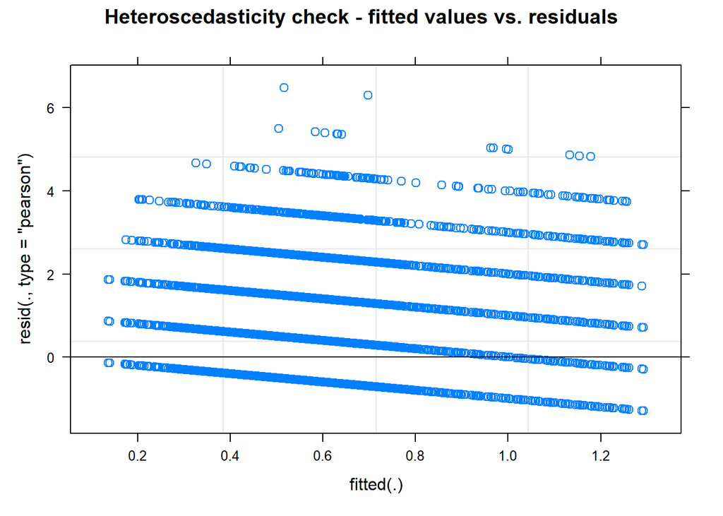

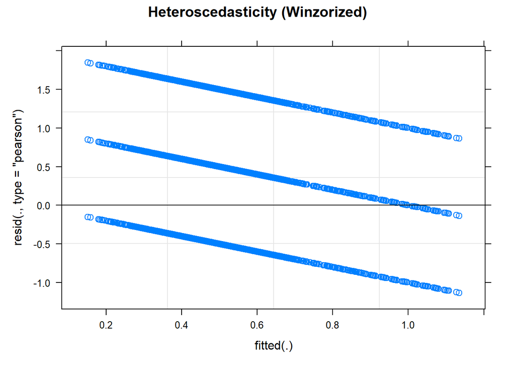

The variance of residuals seems consistent across all levels - so no notable heteroscedasticity?

Not too sure how to interpret these plots - but I think this one isn’t great

In particular, the residuals don’t appear to be symmetrically distributed (tending to cluster towards the middle of the plot). For low fitted values, residuals seem to be skewed higher, leveling off as the fitted values get larger

> There is a two-parameter version of the Box-Cox transformation that allows a shift before transformation:usual Box-Cox transformation sets λ2=0. One common choice with the two-parameter version is λ1=0 and λ2=1 which has the neat property of mapping zero to zero. There is even an R function for this: log1p(). More generally, both parameters can be estimated. In R, the boxcox.fit() function in package geoR will fit the parameters.
> - Inverse hyperbolic sine (IHS) transformation, mixture models (https://robjhyndman.com/hyndsight/transformations/) Other options:
> - we want to obtain heteroskedasticity robust standard errors and their corresponding t values. In R the function coeftest from the lmtest package can be used in combination with the function vcovHC from the sandwich package to do this.

https://stackoverflow.com/questions/48479984/r-mixed-model-with-heteroscedastic-data-only-lm-function-works

> The sandwich package is not limited to lm/glm only but it is in principle object-oriented, see vignette(“sandwich-OOP”, package = “sandwich”) (also published as doi:10.18637/jss.v016.i09.

> There are suitable methods for a wide variety of packages/models but not for nlme or lme4. The reason is that it’s not so obvious for which mixed-effects models the usual sandwich trick actually works. (Disclaimer: But I’m no expert in mixed-effects modeling.)

> However, for lme4 there is a relatively new package called merDeriv (https://CRAN.R-project.org/package=merDeriv) that supplies estfun and bread methods so that sandwich covariances can be computed for lmer output etc. There is also a working paper associated with that package: https://arxiv.org/abs/1612.04911

**Snijders & Bosker, on sandwich estimators (p. 173)** > sandwich estimators for standard errors, also called cluster-robust standard errors, make no assumptions about the distributional shape of the random coefficients. Verbeke and Lesaffre (1997) and Yan and Bentler (2002) proposed sandwich estimators to provide standard errors applicable for nonnormalily distributed random effects… However, sandwich estimators do require large enough numbers of units at the highest level; see Verbeke and Lesaffre 997), Maas and Hox (2004), and hthe further discussion in 12.2 * https://www.r-econometrics.com/methods/hcrobusterrors/

> For a heteroskedasticity robust F test we perform a Wald test using the waldtest function, which is also contained in the lmtest package. It can be used in a similar way as the anova function, i.e., it uses the output of the restricted and unrestricted model and the robust variance-covariance matrix as argument vcov. Based on the variance-covariance matrix of the unrestriced model we, again, calculate White standard errors.

knief and Forstmeier, 2021 > Most elegantly,heteroscedasticity can be modeled directly, for instance by using the “weights” argument in lme (see Pinheiro & Bates, 2000, p. 214), which also enables us to test directly whether allowing for heteroscedasticity increases the fit of the model significantly. Similarly, heteroscedasticity-consistent standard errors could be estimated (Hayes & Cai, 2007). For more advice on handling heteroscedasticity, see McGuinness (2002).

> we did not cover collinearity between predictors or the distribution of random effects, but others have dealt with these aspects before (Freckleton, 2011; Schielzeth et al., 2020).

## 6.4 Multicolinnearity

- **Check**: VIF/tolerances
- **Fix** remove values >= 5

```r
car::vif(m1_sample) # display VIF values
```

```
   gini_2004_6_cent scale(gdppc_2004_6)            age_cent            employed
           1.532014            1.531415            1.068998            1.098780
               male
           1.029239
```

poisson assumptions * rate at which events occur is constant * occurence of one event does not affect occurence of a subsequent event

Probability Mass Function (PMF) - how likely a given value is

cumulative distribution function - all of the likelihoods of values up to and including the designated value

GEE: GENERALIZED LINEAR MODELS FOR DEPENDENT DATA (https://cehs-research.github.io/eBook_multilevel/gee-count-outcome-epilepsy.html)

**Snijders & Bosker, on Generalized Estimating Equations (GEE) (p. 1198)**

- assumes linear or genarlized linear model for the *expected values* of de[emdemt variable in a multilevel data structure, conditional on the explanatory variables
- No assumptions made with respect to the variances and correlations, except that these are independent between highest-level units
- linear model parameters estimated through a working model
- standard errors estimated through sandwich estimator
- comparison between GEE and HLM discussed in Gardiner et al. 2009
- LARGE SAMPLE METHOD - without large sample, need a tailored small-sample version with a differently defined sandwich estimators

Match Poisson Regresssion (GLM)

restricted maximum likelihood (REML)

Thus REML, by accounting for the loss in degrees of freedom from estimating the fixed effects, provides an unbiased estimate of variance components, while ML estimators for variance components are biased under assumptions of normality, since they use estimated fixed effects rather than the true values.

lmeresampler provides an easy way to bootstrap nested linear-mixed effects models using either the parametric, residual, cases, CGR (semi-parametric), or random effects block (REB) bootstrap fit using either lme4 or nlme. The output from lmeresampler is an lmeresamp http://aloy.github.io/lmeresampler/

bootMer

https://www.juliapilowsky.com/2018/10/19/a-practical-guide-to-mixed-models-in-r/ Semi-parametric multilevel modeling (Tihomir Asparouhov)

Probably the advice on this site will be to start with what kind of data your dependent variable is, and then choose an appropriate glm or regression approach. That is, if your dv is count, perhaps Poisson or negative binomial regression. If your dv is concentration, perhaps gamma regression. –

Note that the negative binomial and gamma distributions can only handle positive numbers, and the Poisson distribution can only handle positive whole numbers

# 7 Limitations

The most notable weakness is that this is data from WEIRD countries. Other, less WEIRD countries (e.g., phillipines, nigeria, india) are better represented throughout sweeps 2 to 4

- Unaccounted third variables